# Positron e Quarto

Ambiente de trabalho e documentos reproduzíveis

Alexandre Nicolella

José de Jesus Filho

## Objetivos da aula

- distinguir linguagem, IDE e sistema de publicação;
- reconhecer os componentes do Positron;
- selecionar R ou Python;
- criar um ambiente virtual de Python;
- instalar e verificar o Quarto;
- renderizar um documento `.qmd` mínimo.

## Três funções diferentes

| Componente | Função |
| --- | --- |
| R ou Python | interpretar e executar o código |
| Positron | organizar arquivos, sessões e execução |
| Quarto | transformar a fonte em documento de leitura |

Uma IDE não substitui as linguagens. O Quarto não substitui o editor nem o interpretador.

## Instalação do Positron

## Download no Windows

[figure not shown]

Página oficial de download do Positron

Em computadores usuais com processador Intel ou AMD, utilize **Windows x64**. ARM64 deve ser escolhida apenas para essa arquitetura.

## Procedimento de instalação

1. Baixe o instalador na [página oficial](https://positron.posit.co/download.html).
2. Execute o arquivo.
3. Mantenha a opção de incluir `positron` no `PATH`.
4. Conclua a instalação.
5. Abra o Positron.

No terminal, a versão pode ser verificada com:

```powershell
positron --version
```

## Abrindo a pasta de trabalho

Use **File > Open Folder** e selecione a pasta principal do projeto.

A pasta aberta aparece no topo do Explorer e passa a funcionar como referência para:

- caminhos relativos;
- terminal integrado;
- controle de versões;
- agentes que examinam o projeto.

Abrir a pasta principal é diferente de abrir apenas um arquivo isolado.

## Componentes do Positron

[figure not shown]

Editor, console, terminal, objetos, Explorer e gráficos

## Explorer e editor

**Explorer**

- mostra pastas e arquivos;
- identifica a raiz do projeto;
- altera arquivos reais do computador.

**Editor**

- contém scripts e documentos salvos;
- preserva a sequência do trabalho;
- permite revisar antes de executar.

## Console e terminal

| Local | Recebe | Exemplo |
| --- | --- | --- |
| Console R | código R | `mean(c(1, 2, 3))` |
| Console Python | código Python | `sum([1, 2, 3])` |
| Terminal | comandos do sistema | `python --version` |

O console mantém uma sessão da linguagem. O terminal executa programas e comandos do sistema operacional.

## Objetos e gráficos

O painel **Variables** permite inspecionar objetos existentes na sessão.

O painel **Plots** recebe gráficos produzidos pelo código.

Esses painéis facilitam a inspeção, mas não substituem o registro das operações nos scripts.

## Seleção de R e Python

## Qual interpretador está ativo?

No console de R:

```r
R.version.string
```

No console de Python:

```python
import sys
print(sys.executable)
print(sys.version)
```

Se houver mais de uma instalação, selecione explicitamente aquela que pertence ao projeto.

## Ambiente virtual do Python

Um ambiente virtual associa ao projeto:

- uma versão compatível do Python;
- um conjunto próprio de pacotes;
- dependências isoladas dos demais trabalhos.

Em regra, cria-se um ambiente por projeto. A pasta costuma receber o nome `.venv`.

## Antes de criar a `.venv`

Abra **Terminal > New Terminal** e confirme a pasta:

```powershell
Get-Location
```

O resultado deve ser a raiz do projeto, não uma pasta do sistema como `C:\Windows\System32`.

Confira as versões instaladas:

```powershell
py list
```

## Criando o ambiente

```powershell
py -V:3.14 -m venv .venv
```

Quando o Positron perguntar se deve selecionar o novo ambiente para a pasta, escolha **Yes**.

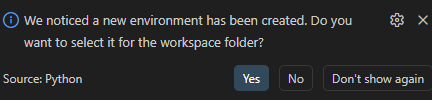

Seleção do ambiente virtual

## Ativação e verificação

```powershell
.\.venv\Scripts\Activate.ps1
python --version
python -c "import sys; print(sys.executable)"
```

O início da linha costuma mostrar `(.venv)`. O executável deve terminar em `.venv\Scripts\python.exe`.

## Sessão Python no Positron

1. Abra a Paleta de Comandos com `Ctrl + Shift + P`.
2. Execute **Interpreter: Discover All Interpreters**.
3. Execute **Interpreter: Start New Console Session**.
4. Selecione a `.venv` do projeto.

[figure not shown]

Sessão Python iniciada com a `.venv`

## A `.venv` não entra no Git

O arquivo `.gitignore` deve conter:

```
.venv/
```

A `.venv` é reconstruível e permanece no computador. O `.gitignore`, ao contrário, integra o projeto e deve ser preservado.

Para encerrar a ativação naquele terminal:

```powershell
deactivate
```

## Quarto

## O que é o Quarto?

O Quarto combina:

- prosa e referências;
- equações, tabelas e figuras;
- código executável e seus resultados.

O arquivo-fonte possui extensão `.qmd`. A renderização produz HTML, PDF, Word, slides ou livros.

## Instalação do Quarto

[figure not shown]

Instalador do Quarto para Windows

Baixe o instalador `.msi`, conclua o assistente e reabra o terminal.

## Verificação do Quarto

```powershell
quarto --version
quarto check
```

O primeiro comando informa a versão. O segundo examina o Quarto e as integrações disponíveis.

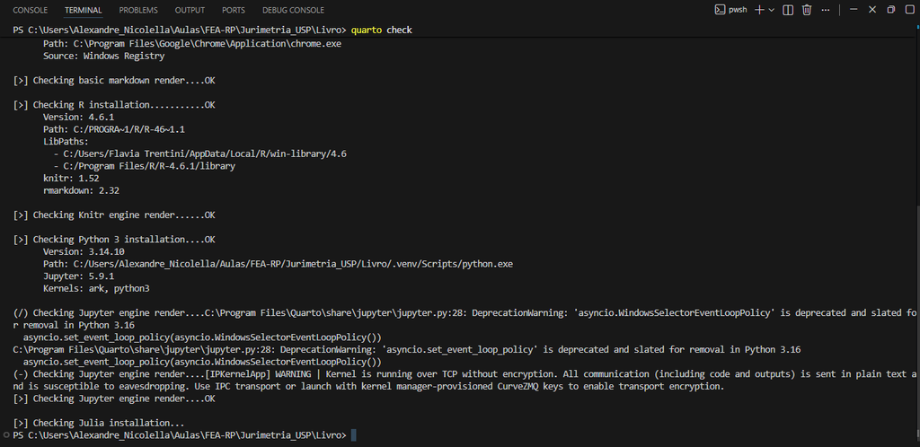

Resultado de `quarto check`

## Quando o Jupyter é necessário?

A sessão Python do Positron não exige uma instalação separada do Jupyter.

O Jupyter é necessário quando o **Quarto executa blocos Python durante a renderização**. Se o documento utiliza somente R, essa instalação não é necessária.

## Jupyter na `.venv`

```powershell
.\.venv\Scripts\python.exe -m pip install jupyter
.\.venv\Scripts\python.exe -m jupyter --version
```

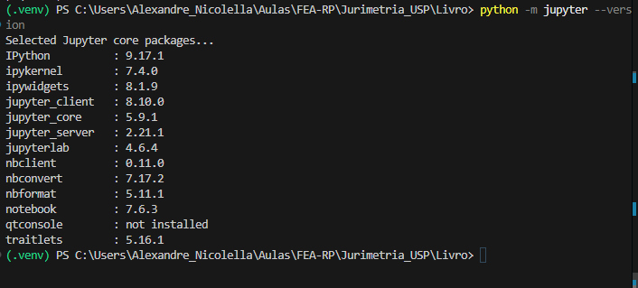

Componentes do Jupyter instalados na `.venv`

## Verificação pelo Quarto

```powershell
.\.venv\Scripts\Activate.ps1
quarto check jupyter
```

O resultado deve mostrar:

- o interpretador dentro de `.venv`;
- a instalação do Python localizada;
- o Jupyter disponível.

## Primeiro documento Quarto

## Cabeçalho e texto

Crie `exemplo.qmd`:

```markdown
---
title: "Exemplo jurídico"
format: html
---

## Uma tabela simples

O documento combina texto, código e resultado.
```

O bloco inicial é o YAML e deve começar na primeira linha.

## Bloco de código

````markdown
```r
estados <- c("Acre", "Alagoas", "Amapá")
feminicidios <- c(11, 31, 8)

data.frame(
  estado = estados,
  feminicidios = feminicidios
)
```
````

## Renderização

No terminal, na pasta do arquivo:

```powershell
quarto render exemplo.qmd
```

Em um arquivo isolado, o HTML tende a aparecer ao lado da fonte. Em um projeto, `_quarto.yml` pode definir outro destino, como `docs/`.

## Fonte e produto

| Arquivo | Natureza | Conduta |
| --- | --- | --- |
| `exemplo.qmd` | fonte | escrever, revisar e preservar |
| `exemplo.html` | resultado | abrir para leitura e verificação |
| `exemplo_files/` | dependências geradas | manter quando o HTML depender dela |

Não edite diretamente o HTML. A próxima renderização pode substituir a alteração.

## Erros frequentes

**YAML inválido:** existe conteúdo antes do primeiro `---`.

**Arquivo não encontrado:** o caminho relativo não corresponde à raiz da renderização.

**Linguagem ou pacote ausente:** o Quarto utiliza outro R ou outro ambiente Python.

Leia primeiro a mensagem que identifica o arquivo, a linha ou o bloco responsável.

## Verificação final

- A raiz correta está aberta no Explorer?
- Distingo editor, console e terminal?
- Sei qual R ou Python está ativo?
- A `.venv` está na raiz e no `.gitignore`?
- `quarto --version` e `quarto check` funcionam?
- Sei distinguir `.qmd` de `.html`?